# Kickstarter Project - xgBoost Models Trainings and Tuning

First of all, we need to load all the necessary libraries. Also make sure your working directory has a folder called `model` which contains all the caret objects. Otherwise this script will probably take couple days to run.

```r
library(caret)
library(xgboost)
library(ROCR)
```

We will also need to load and preprocess the data.

```r
# load rds object
train <- readRDS('../rdata/df_initital_success_train.rds')
val <- readRDS('../rdata/df_initital_success_validate.rds')
# create one-hot-encoded model matrix (for caret)
mmtd<-model.matrix(state~., data=train)
mmtd<-mmtd[,2:ncol(mmtd)]
mmtl<-train$state
mmvd<-model.matrix(state~., data=val)
mmvd<-mmvd[,2:ncol(mmvd)]
mmvl<-val$state
# create xgb.DMatrix (for xgboost)
dtrain<-xgb.DMatrix(data=mmtd, label=mmtl)
dval<-xgb.DMatrix(data=mmvd, label=mmvl)
```

After that, we define the general `trControl` object.

```r
# define general trControl
tC = trainControl(method="cv", number=5, verboseIter = TRUE)
```

We then define the parameters for our first sweep. ref: https://www.analyticsvidhya.com/blog/2016/03/complete-guide-parameter-tuning-xgboost-with-codes-python/

```r
# first sweep
tGrid=expand.grid(eta=seq(0.1,0.5,0.1),
                  max_depth=seq(1,6,1),
                  subsample=c(0.5,1),
                  nrounds=1000,
                  gamma=c(0,1),
                  colsample_bytree=1,
                  min_child_weight=1)
```

Due to time constraint, a trained caret object could be used provided it’s in the working environment. Otherwise, the actual training will starts (takes ~7 hours or more)

```r
# load caret train object if exists, otherwise run caret train
if (file.exists('../model/xgbt.caret')) {
  load('../model/xgbt.caret')
  } else {
  xgbt<-train(x=mmtd, y=mmtl, method='xgbTree', metric='Accuracy', maximize=TRUE, tuneGrid = tGrid, trControl=tC, num.threads = 7)
  save(xgbt, file = '../model/xgbt.caret')
  }
```

With the train object, we could first take a look at the plots from the all the tuning parameters.

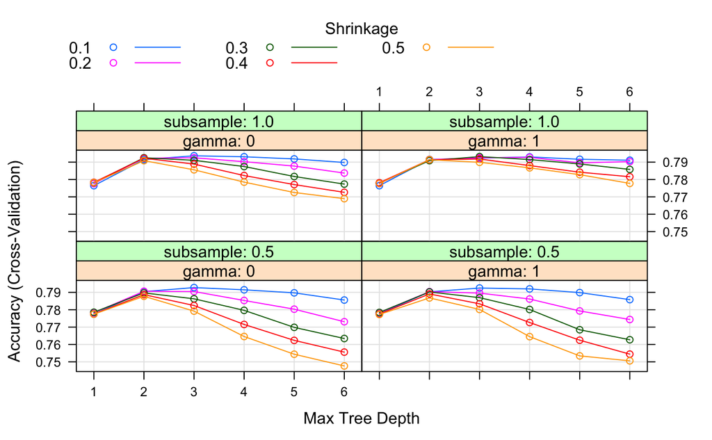

```r
plot(xgbt)
```

```r
xgbt$bestTune
```

|  | nrounds | max_depth | eta | gamma | colsample_bytree | min_child_weight | subsample |
| --- | --- | --- | --- | --- | --- | --- | --- |
| 10 | 1000 | 3 | 0.1 | 0 | 1 | 1 | 1 |

It’s clear that a lower shrinkage value (`eta`) and a Max Tree Depth of 3 improves accuracy slightly, while changing subsampling and gamma didn’t have huge impact.

Let’s take a look at the features importance.

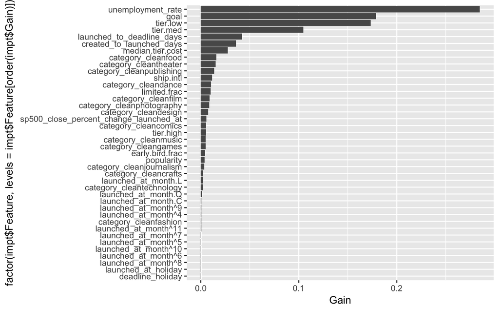

```r
impt<-xgb.importance(xgbt$finalModel$xNames, xgbt$finalModel)
ggplot(impt, aes(factor(impt$Feature, levels = impt$Feature[order(impt$Gain)]), Gain)) +geom_bar(stat = "identity") + coord_flip()
```

```r
impt
```

| Feature | Gain | Cover | Frequency |
| --- | --- | --- | --- |
| unemployment_rate | 2.847943e-01 | 8.000352e-02 | 0.116827279 |
| goal | 1.786845e-01 | 1.127550e-01 | 0.117123795 |
| tier.low | 1.734865e-01 | 5.732285e-02 | 0.055744996 |
| tier.med | 1.044792e-01 | 4.250996e-02 | 0.041957005 |
| launched_to_deadline_days | 4.207329e-02 | 1.237145e-01 | 0.106449222 |
| created_to_launched_days | 3.578820e-02 | 1.098889e-01 | 0.104521868 |
| median.tier.cost | 2.739896e-02 | 1.001165e-01 | 0.088806523 |
| category_cleanfood | 1.597288e-02 | 1.032677e-02 | 0.015863603 |
| category_cleantheater | 1.504480e-02 | 1.663826e-02 | 0.009785026 |
| category_cleanpublishing | 1.360915e-02 | 2.961511e-02 | 0.014084507 |

[output cut: 30 more lines]

From the bar-chart in descending order, we can see `unemployment_rate` has the biggest impact to the model, while `launched_at_month` barely provided any impact.

Before removing any features, another sweep is conducted to observe the impact of xgBoost iterations to accuracy. We took a look at the difference between 1000 - 5000 iterations.

```r
#second sweep
tGrid=expand.grid(eta=0.1,
                  max_depth=3,
                  subsample=1,
                  nrounds=seq(1000,5000,100),
                  gamma=0,
                  colsample_bytree=1,
                  min_child_weight=1)
```

```r
# load caret train object if exists, otherwise run caret train
if (file.exists('../model/xgbt2.caret')) {
  load('../model/xgbt2.caret')
  } else {
  xgbt2<-train(x=mmtd, y=mmtl, method='xgbTree', metric='Accuracy', maximize=TRUE, tuneGrid = tGrid, trControl=tC, num.threads = 7)
  save(xgbt2, file = '../model/xgbt2.caret')
  }
```

[figure not shown]

```r
plot(xgbt2)
```

```r
xgbt2$bestTune
```

|  | nrounds | max_depth | eta | gamma | colsample_bytree | min_child_weight | subsample |
| --- | --- | --- | --- | --- | --- | --- | --- |
| 1 | 1000 | 3 | 0.1 | 0 | 1 | 1 | 1 |

It’s clear that as the model goes through more iterations, the lower the accuracy (though not by a lot). But what about lower iterations? We will do another sweep! This time, from 100 - 2000 iterations.

```r
#third sweep
tGrid=expand.grid(eta=0.1,
                  max_depth=3,
                  subsample=1,
                  nrounds=seq(100,2000,100),
                  gamma=0,
                  colsample_bytree=1,
                  min_child_weight=1)
```

```r
# load caret train object if exists, otherwise run caret train
if (file.exists('../model/xgbt3.caret')) {
  load('../model/xgbt3.caret')
  } else {
  xgbt3<-train(x=mmtd, y=mmtl, method='xgbTree', metric='Accuracy', maximize=TRUE, tuneGrid = tGrid, trControl=tC, num.threads = 7)
  save(xgbt3, file = '../model/xgbt3.caret')
  }
```

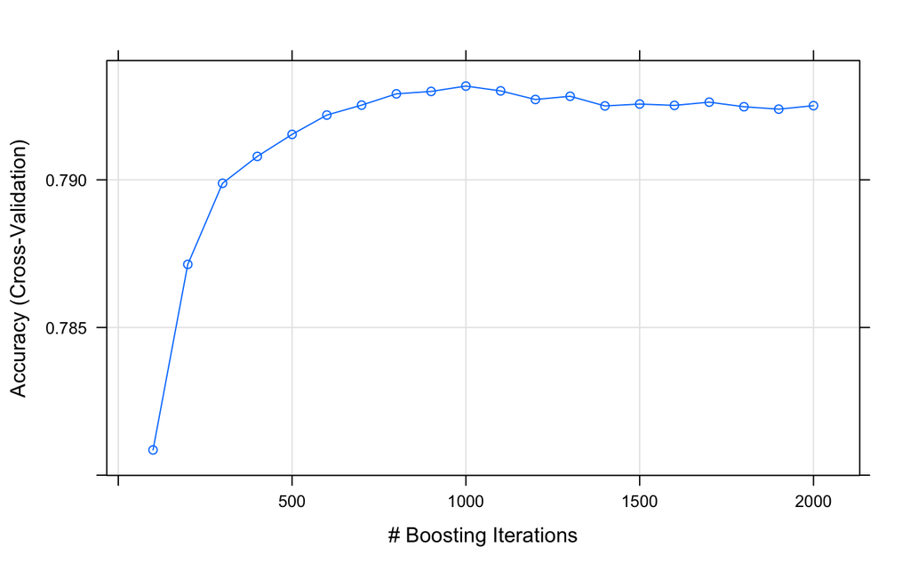

```r
plot(xgbt3)
```

```r
xgbt3$bestTune
```

|  | nrounds | max_depth | eta | gamma | colsample_bytree | min_child_weight | subsample |
| --- | --- | --- | --- | --- | --- | --- | --- |
| 10 | 1000 | 3 | 0.1 | 0 | 1 | 1 | 1 |

Looks like the accuracy plateaued at 1000 iterations (again, not by a lot). We will continue future sweep with 1000 iterations set.

Going back to the first sweep where ``launched_at_month` contributed little to the model, we also see `launched_at_holiday` and `deadline_holiday` provided little impact to the model as well. This suggests the success of a Kickstarter project has little to do with if the project is launched in a particular month, launched during a holiday, or ended during a holiday.

Since these features are not important, let’s remove them from the model and do another parameter sweep (with additional parameters). This time, we will look at further impact from `gamma` and `colsample_bytree`. We will also look at shrinkage factor as the first sweep suggested a lower value improves the prediction.

```r
# remove unwanted columns
remove <- grep('launched_at_month|launched_at_holiday|deadline_holiday', names(train))
train <- train[-remove]
val <- val[-remove]
# remove features
mmtd<-model.matrix(state~., data=train)
mmtd<-mmtd[,2:ncol(mmtd)]
mmtl<-train$state
mmvd<-model.matrix(state~., data=val)
mmvd<-mmvd[,2:ncol(mmvd)]
mmvl<-val$state
# create xgb.DMatrix (for xgboost)
dtrain<-xgb.DMatrix(data=mmtd, label=mmtl)
dval<-xgb.DMatrix(data=mmvd, label=mmvl)
```

```r
#final sweep
tGrid=expand.grid(eta=seq(0.01,0.1,0.01),
                  max_depth=3,
                  subsample=1,
                  nrounds=1000,
                  gamma=c(0,1,5,10),
                  colsample_bytree=seq(0.2,1,0.1),
                  min_child_weight=1)
```

```r
# load caret train object if exists, otherwise run caret train
if (file.exists('../model/xgbtf.caret')) {
  load('../model/xgbtf.caret')
  } else {
  xgbtf<-train(x=mmtd, y=mmtl, method='xgbTree', metric='Accuracy', maximize=TRUE, tuneGrid = tGrid, trControl=tC, num.threads = 7)
  save(xgbtf, file = '../model/xgbtf.caret')
  }
```

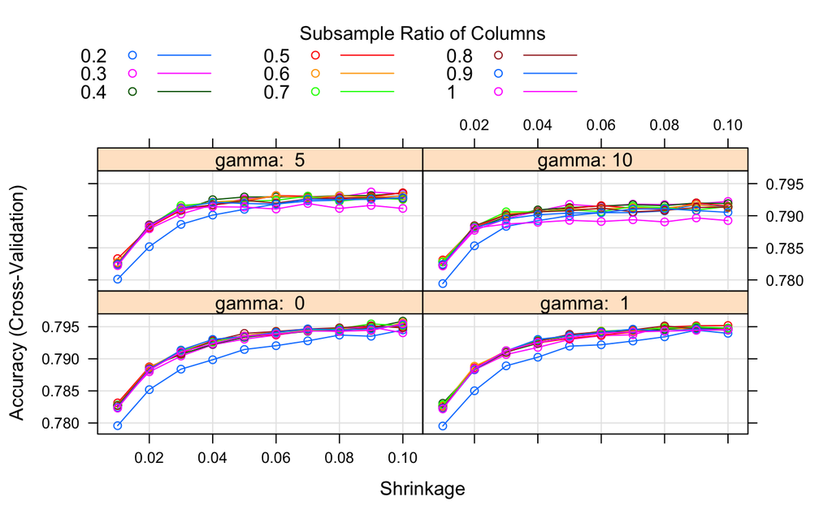

```r
plot(xgbtf)
```

```r
xgbtf$bestTune
```

|  | nrounds | max_depth | eta | gamma | colsample_bytree | min_child_weight | subsample |
| --- | --- | --- | --- | --- | --- | --- | --- |
| 327 | 1000 | 3 | 0.1 | 0 | 0.4 | 1 | 1 |

It looks like no matter what, the tuning could not break the curse of 80 % accuracy - this might be the limitation of the features we engineered. The tuning plot shows that a `gamma` of 0 provides the highest accuracy, while the accuracy changes from modifying `eta` stabilizes as it approaches 0.1. Finally, `colsample_bytree` of 0.4 gives the highest accuracy (again, not by a lot). This will be the final model before submitting to the validation data.

```r
final_xgb <- xgb.train(data=dtrain, max.depth=3, eta=0.1, gamma=0, colsample_by_tree=0.4, min_child_weight=1, subsample=1,nthread = 7, nround=1000, objective = "binary:logistic")
```

With the final model, let’s take a look at the features importance again.

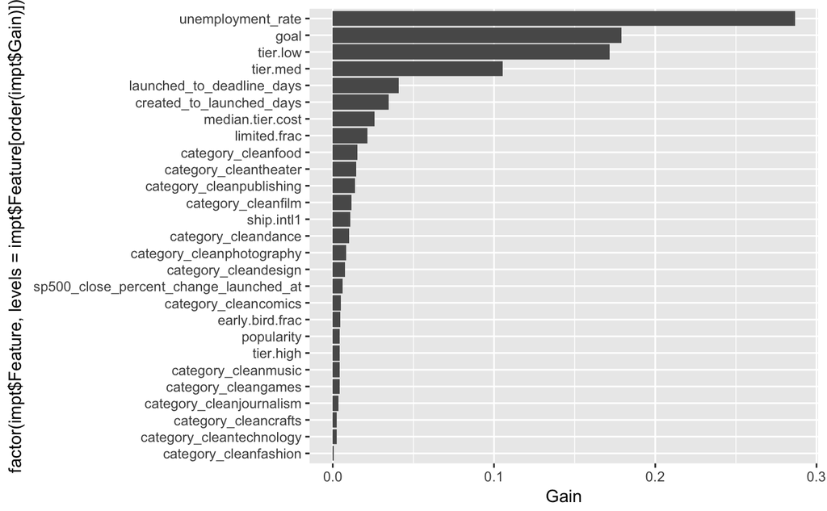

```r
impt<-xgb.importance(colnames(dtrain), final_xgb)
ggplot(impt, aes(factor(impt$Feature, levels = impt$Feature[order(impt$Gain)]), Gain)) +geom_bar(stat = "identity") + coord_flip()
```

```r
impt
```

| Feature | Gain | Cover | Frequency |
| --- | --- | --- | --- |
| unemployment_rate | 0.2868155810 | 0.086759339 | 0.125444840 |
| goal | 0.1788873726 | 0.113861553 | 0.114472123 |
| tier.low | 0.1718668949 | 0.051576411 | 0.053084223 |
| tier.med | 0.1055087339 | 0.036436776 | 0.039739027 |
| launched_to_deadline_days | 0.0410649912 | 0.134958529 | 0.111358244 |
| created_to_launched_days | 0.0345734432 | 0.109069234 | 0.105575326 |
| median.tier.cost | 0.0260443112 | 0.097361854 | 0.090005931 |
| limited.frac | 0.0213824502 | 0.026266400 | 0.041370107 |
| category_cleanfood | 0.0154388763 | 0.011406309 | 0.016162515 |
| category_cleantheater | 0.0144694626 | 0.017422982 | 0.008748517 |

[output cut: 17 more lines]

This looks similar to the one before. The final step is to look at the validation accuracy.

```r
pred <- predict(final_xgb, dval)
table(mmvl, pred > 0.5)
```

```
mmvl FALSE TRUE
   0  4328 1666
   1  1093 6659
```

```r
sum(diag(table(mmvl, pred > 0.5)))/length(mmvl)
```

```
[1] 0.7992871
```

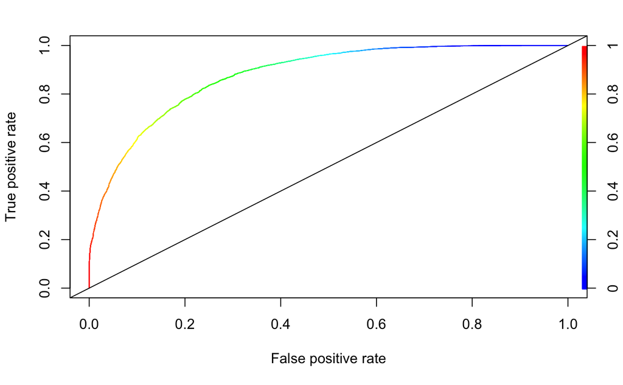

```r
rocr.pred <- prediction(pred, mmvl)
logPerformance <- performance(rocr.pred, "tpr", "fpr")
plot(logPerformance, colorize = TRUE)
abline(0, 1)
```

```r
as.numeric(performance(rocr.pred, "auc")@y.values)
```

```
[1] 0.8786106
```

```r
# save the model matrix
save(mmtd, file = '../rdata/mmtd.rda')
save(mmtl, file = '../rdata/mmtl.rda')
save(mmvd, file = '../rdata/mmvd.rda')
save(mmvl, file = '../rdata/mmvl.rda')
```

```r
# misc notes
```

```
#> (6677+4274)/nrow(val)
```

```r
#[1] 0.7966681                <--base (xdb.DMatrix) (not using OHE)
```

```
#> (6663+4311)/nrow(val)
```

```r
#[1] 0.7983413                 <- using OHE
```

```
#> (6644+4335)/nrow(val)
```

```r
#[1] 0.7987051               <- remove month + using OHE
```

```
#> (6659+4328)/nrow(val)
```

```r
#[1] 0.7992871             <- remove month / launched_at_holiday / deadline_holiday, + using OHE
```